# Simulation results 1

Fixed design with single look at data

Published

June 20, 2025

Modified

May 6, 2025

Simulation 1 is a fixed sized trial with decision criteria for superiority, and non-inferiority and also for futility with respect to both superiority and non-inferiority.

We provide summaries of each simulation scenario and the results that were obtained.

**Load simulation results**

```r
# files of interest
flist <- list.files("data", pattern = "sim01-sc01")
toks <- list()
l <- list()
for(i in 1:length(flist)){
  l[[i]] <- qs::qread(file.path("data", flist[i]))
  toks[[i]] <-  unlist(tstrsplit(flist[i], "[-.]"))
}
```

**Configuration used for each simulated scenario**

```r
# cfg used in each scenario
d_cfg <- rbindlist(lapply(seq_along(l), function(i){
  tok <- toks[[i]]
  m <- data.table(do.call(cbind, l[[i]]$cfg))
  data.table(cbind(sc = tok[2], v = tok[3], analys = 1:nrow(m), m))
}))

# conversion to numeric
d_cfg[, `:=`(
  nsim = as.numeric(nsim),
  N_pt = as.numeric(N_pt),
  b_r1 = as.numeric(b_r1),
  b_r2 = as.numeric(b_r2),
  w_srp2 = as.numeric(w_srp2),
  b_r1d = as.numeric(b_r1d),
  b_r2d = as.numeric(b_r2d),
  b_f = as.numeric(b_f),
  d_sup = as.numeric(thresh_sup),
  d_ni = as.numeric(thresh_non_inf),
  d_fut_sup = as.numeric(thresh_fut_sup),
  d_fut_ni = as.numeric(thresh_fut_ni)
  )]

d_cfg[, `:=`(w_srp2 = NULL)]
```

**Process simulation results for variables of interest**

```r
# Decisions
i <- 1


d_sup <- rbindlist(lapply(seq_along(l), function(i){
  cbind(sc = d_cfg[i, sc], v = d_cfg[i, v], l[[i]]$d_sup[, lapply(.SD, mean)])
}))
d_sup <- melt(d_sup, id.vars = c("sc", "v"), value.name = "p")
d_sup[, type := "sup"]

d_trt_ni_ref <- rbindlist(lapply(seq_along(l), function(i){
  cbind(sc = d_cfg[i, sc], v = d_cfg[i, v], l[[i]]$d_pr_trt_ni_ref[, lapply(.SD, mean)])
}))
d_trt_ni_ref <- melt(d_trt_ni_ref, id.vars = c("sc", "v"), value.name = "p")
d_trt_ni_ref[, type := "trt_ni_ref"]

d_fut_sup <- rbindlist(lapply(seq_along(l), function(i){
  cbind(sc = d_cfg[i, sc], v = d_cfg[i, v], l[[i]]$d_fut_sup[, lapply(.SD, mean)])
}))
d_fut_sup <- melt(d_fut_sup, id.vars = c("sc", "v"), value.name = "p")
d_fut_sup[, type := "fut_sup"]

d_fut_ni <- rbindlist(lapply(seq_along(l), function(i){
  cbind(sc = d_cfg[i, sc], v = d_cfg[i, v], l[[i]]$d_fut_trt_ni_ref[, lapply(.SD, mean)])
}))
d_fut_ni <- melt(d_fut_ni, id.vars = c("sc", "v"), value.name = "p")
d_fut_ni[, type := "fut_ni"]

d_dec <- rbind(
  d_sup, d_trt_ni_ref, d_fut_sup, d_fut_ni
)

n_sims <- d_cfg$nsim[1]
N_pt <- d_cfg$N_pt[1]


# Posterior summaries on effects of interest
d_post_smry_2 <- rbindlist(lapply(seq_along(l), function(i){
  tok <- toks[[i]]
  m <- l[[i]]$d_post_smry_2
  cbind(sc = tok[2], v = tok[3], m)
}))

# Participant data from trial (grouped)
d_all <- rbindlist(lapply(seq_along(l), function(i){
  tok <- toks[[i]]
  m <- l[[i]]$d_grp
  cbind(sc = tok[2], v = tok[3], m)
}))
```

Table 1 summarises the configurations used in each simulated scenario. Each treatment effect parameter is set to have the same magnitude of effect. The effects range from $\log(1/2)$ in scenario 1 to $\log(2)$ in scenario 7. Decision rules and thresholds remain constant over the entire enrolment period.

Revision effects are computed as a weighted combination of the log-odds ratios for the one-stage and two-stage revision effects. The weights are the sample proportion receiving one-stage and two-stage surgery in those patients receiving randomised surgical treatment and randomised to revision.

```r
d_tbl <- d_cfg[, .(v, N_pt, b_r1, b_r2, b_r1d, b_r2d, b_f,
                   delta_sup = delta_sup,
                   delta_sup_fut = delta_sup_fut,
                   delta_ni = 1/delta_ni,
                   thresh_sup, thresh_non_inf, thresh_fut_sup, thresh_fut_ni)]

g_tbl <- d_tbl |> gt() |>
  cols_align(
    columns = everything(),
    align = "center"
  )  |>
  fmt_number(
    columns = c(b_r1, b_r2, b_r1d, b_r2d, b_f,
                delta_ni
                ),
    decimals = 3
  ) |>
  tab_spanner(
    label = html("Surgical (D<sub>a</sub>)"),
    columns = c(b_r1, b_r2)
  ) |>
  tab_spanner(
    label = html("Duration (D<sub>b</sub>)"),
    columns = c(b_r1d, b_r2d)
  ) |>
  tab_spanner(
    label = html("Type (D<sub>c</sub>)"),
    columns = c(b_f)
  ) |>
  tab_spanner(
    label = html("Decision setup"),
    columns = c(delta_sup, thresh_sup,
                delta_sup_fut, thresh_fut_sup,
                delta_ni, thresh_non_inf, thresh_fut_ni)
  ) |>
  cols_label(
    v = html("Configuration"),
    b_r1 = html("rev<br>(one-stage)"),
    b_r2 = html("rev<br>(two-stage)"),
    b_r1d = html("short<br>(one-stage)"),
    b_r2d = html("short<br>(two-stage)"),
    b_f = html("rif"),
    delta_sup = html("delta<sub>sup</sub>"),
    thresh_sup = html("p<sub>sup</sub>"),
    delta_sup_fut = html("delta<sub>fut-sup</sub>"),
    thresh_fut_sup = html("p<sub>fut-sup</sub>"),
    delta_ni = html("delta<sub>ni</sub>"),
    thresh_non_inf = html("p<sub>ni</sub>"),
    thresh_fut_ni = html("p<sub>fut-ni</sub>")
  ) |>
  tab_style(
    style = list(
      cell_borders(
        sides = c("bottom"), color = "black", weight = px(1), style = "solid"
      )),
    locations = list(
      cells_body(
        columns = everything(),
        rows = N_pt == 2500
      )
    )
  ) |>
  tab_options(
    table.font.size = "70%"
  ) |>
  tab_footnote(
    footnote = "Surgical effects only applies to late silo, effect is relative to response under DAIR.",
    locations = cells_column_labels(columns = c(b_r1, b_r2))
  ) |>
  tab_footnote(
    footnote = "Applies to all silos, effect is relative to response under long duration.",
    locations = cells_column_labels(columns = b_r1d)
  ) |>
  tab_footnote(
    footnote = "Applies to all silos, effect is relative to response under short duration.",
    locations = cells_column_labels(columns = b_r2d)
  ) |>
  tab_footnote(
    footnote = "Applies to all silos, effect is relative to response under no-rifampicin",
    locations = cells_column_labels(columns = b_f)
  ) |>
  tab_footnote(
    footnote = "Reference OR for evaluating superiority",
    locations = cells_column_labels(columns = delta_sup)
  ) |>
  tab_footnote(
    footnote = "Probability threshold above which superiority is concluded",
    locations = cells_column_labels(columns = thresh_sup)
  ) |>
  tab_footnote(
    footnote = "Reference OR for evaluating futility wrt the superiority decision",
    locations = cells_column_labels(columns = delta_sup_fut)
  ) |>
  tab_footnote(
    footnote = "Probability threshold below which futility is concluded",
    locations = cells_column_labels(columns = thresh_fut_sup)
  ) |>
  tab_footnote(
    footnote = "Reference OR for evaluating non-inferiority",
    locations = cells_column_labels(columns = delta_ni)
  ) |>
  tab_footnote(
    footnote = "Probability threshold above which non-inferiority is concluded",
    locations = cells_column_labels(columns = thresh_non_inf)
  ) |>
  tab_footnote(
    footnote = "Probability threshold below which non-inferiority decision is deemed futile",
    locations = cells_column_labels(columns = thresh_fut_ni)
  )

g_tbl
```

| Configuration | N_pt | Surgical (D<sub>a</sub>) rev (one-stage)<sup>1</sup> | Surgical (D<sub>a</sub>) rev (two-stage)<sup>1</sup> | Duration (D<sub>b</sub>) short (one-stage)<sup>2</sup> | Duration (D<sub>b</sub>) short (two-stage)<sup>3</sup> | Type (D<sub>c</sub>) rif<sup>4</sup> | Decision setup delta<sub>sup</sub><sup>5</sup> | Decision setup p<sub>sup</sub><sup>6</sup> | Decision setup delta<sub>fut-sup</sub><sup>7</sup> | Decision setup p<sub>fut-sup</sub><sup>8</sup> | Decision setup delta<sub>ni</sub><sup>9</sup> | Decision setup p<sub>ni</sub><sup>10</sup> | Decision setup p<sub>fut-ni</sub><sup>11</sup> |
| --- | --- | --- | --- | --- | --- | --- | --- | --- | --- | --- | --- | --- | --- |
| v01 | 2500 | −0.693 | −0.693 | −0.693 | −0.693 | −0.693 | 1 | 0.975 | 1.2 | 0.05 | 0.833 | 0.975 | 0.05 |
| v02 | 2500 | −0.405 | −0.405 | −0.405 | −0.405 | −0.405 | 1 | 0.975 | 1.2 | 0.05 | 0.833 | 0.975 | 0.05 |
| v03 | 2500 | −0.182 | −0.182 | −0.182 | −0.182 | −0.182 | 1 | 0.975 | 1.2 | 0.05 | 0.833 | 0.975 | 0.05 |
| v04 | 2500 | 0.000 | 0.000 | 0.000 | 0.000 | 0.000 | 1 | 0.975 | 1.2 | 0.05 | 0.833 | 0.975 | 0.05 |
| v05 | 2500 | 0.182 | 0.182 | 0.182 | 0.182 | 0.182 | 1 | 0.975 | 1.2 | 0.05 | 0.833 | 0.975 | 0.05 |
| v06 | 2500 | 0.405 | 0.405 | 0.405 | 0.405 | 0.405 | 1 | 0.975 | 1.2 | 0.05 | 0.833 | 0.975 | 0.05 |
| v07 | 2500 | 0.693 | 0.693 | 0.693 | 0.693 | 0.693 | 1 | 0.975 | 1.2 | 0.05 | 0.833 | 0.975 | 0.05 |

<sup>1</sup> Surgical effects only applies to late silo, effect is relative to response under DAIR.  
<sup>2</sup> Applies to all silos, effect is relative to response under long duration.  
<sup>3</sup> Applies to all silos, effect is relative to response under short duration.  
<sup>4</sup> Applies to all silos, effect is relative to response under no-rifampicin  
<sup>5</sup> Reference OR for evaluating superiority  
<sup>6</sup> Probability threshold above which superiority is concluded  
<sup>7</sup> Reference OR for evaluating futility wrt the superiority decision  
<sup>8</sup> Probability threshold below which futility is concluded  
<sup>9</sup> Reference OR for evaluating non-inferiority  
<sup>10</sup> Probability threshold above which non-inferiority is concluded  
<sup>11</sup> Probability threshold below which non-inferiority decision is deemed futile

Table 1: Parameters used to simulate treatment effects and decision thresholds

Figure 1 summarises the variation in the probability of declaring each decision type on each parameter with increasing effects size (odds ratios). The results based on 5000 simulations for a cohort sample size of 2500.

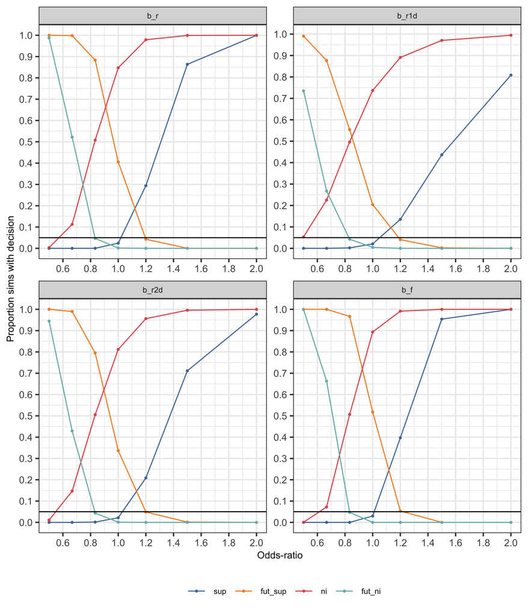

Figure 1: Probability of declaring decision by parameter by effect size (all pars set with same OR).

```r
d_fig <- copy(d_dec)

d_fig[, or := g_or_num[v]]

d_fig[, type := factor(
  type, levels = c("sup", "fut_sup", "trt_ni_ref", "fut_ni"),
  labels = c("sup", "fut_sup", "ni", "fut_ni"))]

ggplot(d_fig, aes(x = or, y = p, group = type, col = type)) +
  geom_point(size = 0.5) +
  geom_line(lwd = 0.4) +
  geom_hline(yintercept = 0.05, lwd = 0.4) +
  ggthemes::scale_colour_tableau(
    "", palette = "Tableau 10",
  type = "regular",
  direction = 1) +
  scale_x_continuous("Odds-ratio", breaks = seq(0, 2, by = 0.2)) +
  scale_y_continuous("Proportion sims with decision", breaks = seq(0, 1, by = 0.1)) +
  facet_wrap(~variable, ncol = 2, scales = "free")
```

Table 2 shows the same detail as the above figure, but makes it easier to see what the magnitudes of the probabilities are.

```r
# Widen data so that power is shown by col with each col corresponding to an
# analysis
d_tbl <- copy(d_fig)
d_tbl <- dcast(d_tbl, variable + or ~ type, value.var = "p")
names(d_tbl) <- gsub("superiority", "sup", names(d_tbl))
names(d_tbl) <- gsub("futility", "fut", names(d_tbl))
names(d_tbl) <- gsub("trt ni ref", "trt_ni_ref", names(d_tbl))
d_tbl <- d_tbl[order(variable, or)]


g_tbl <- d_tbl |> gt(groupname_col = "variable") |>
  cols_label(
    or = html("Odds ratio<br>(true)"),
    sup = html("Superiority"),
    fut_sup = html("Futility (sup)"),
    ni = html("NI (trt ni ref)"),
    fut_ni = html("Futility (ni)"),
  )  |>
  fmt_number(
    columns = everything(),
    decimals = 3
  ) |>
  tab_style(
    style = list(
      cell_borders(
        sides = c("top", "bottom"), color = "red", weight = px(1), style = "solid"
      )),
    locations = list(
      cells_body(
        columns = everything(),
        rows = or == "1"
      )
    )
  ) |>
  tab_options(
    table.font.size = "80%"
  )

g_tbl
```

| Odds ratio (true) | Superiority | Futility (sup) | NI (trt ni ref) | Futility (ni) |
| --- | --- | --- | --- | --- |
| b_r |  |  |  |  |
| 0.500 | 0.000 | 1.000 | 0.003 | 0.988 |
| 0.667 | 0.000 | 0.998 | 0.113 | 0.522 |
| 0.833 | 0.000 | 0.883 | 0.508 | 0.046 |
| 1.000 | 0.024 | 0.406 | 0.847 | 0.002 |
| 1.200 | 0.294 | 0.043 | 0.979 | 0.000 |
| 1.500 | 0.864 | 0.000 | 0.999 | 0.000 |
| 2.000 | 1.000 | 0.000 | 1.000 | 0.000 |
| b_r1d |  |  |  |  |
| 0.500 | 0.000 | 0.991 | 0.053 | 0.735 |
| 0.667 | 0.000 | 0.877 | 0.226 | 0.267 |
| 0.833 | 0.002 | 0.554 | 0.496 | 0.043 |
| 1.000 | 0.021 | 0.204 | 0.737 | 0.005 |
| 1.200 | 0.135 | 0.041 | 0.891 | 0.000 |
| 1.500 | 0.437 | 0.002 | 0.971 | 0.000 |
| 2.000 | 0.809 | 0.000 | 0.995 | 0.000 |
| b_r2d |  |  |  |  |
| 0.500 | 0.000 | 1.000 | 0.011 | 0.945 |
| 0.667 | 0.000 | 0.990 | 0.147 | 0.429 |
| 0.833 | 0.001 | 0.795 | 0.505 | 0.043 |
| 1.000 | 0.022 | 0.337 | 0.812 | 0.001 |
| 1.200 | 0.209 | 0.049 | 0.956 | 0.000 |
| 1.500 | 0.711 | 0.001 | 0.996 | 0.000 |
| 2.000 | 0.977 | 0.000 | 1.000 | 0.000 |
| b_f |  |  |  |  |
| 0.500 | 0.000 | 1.000 | 0.000 | 0.999 |
| 0.667 | 0.000 | 1.000 | 0.072 | 0.663 |
| 0.833 | 0.000 | 0.967 | 0.507 | 0.047 |
| 1.000 | 0.030 | 0.518 | 0.894 | 0.000 |
| 1.200 | 0.397 | 0.053 | 0.991 | 0.000 |
| 1.500 | 0.954 | 0.000 | 1.000 | 0.000 |
| 2.000 | 1.000 | 0.000 | 1.000 | 0.000 |

Table 2: Probability of decision

Figure 2 shows the distribution of estimated posterior means by simulated effect size, parameter and scenario.

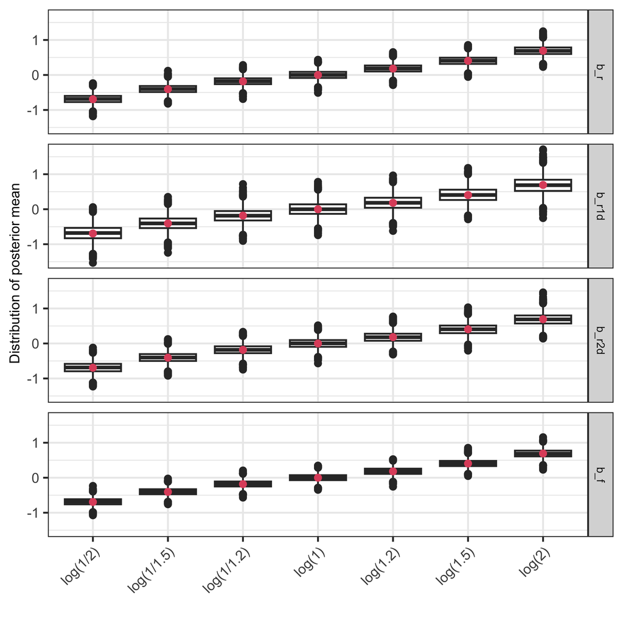

Figure 2: Distribution of posterior means (true log OR shown in red).